# The A-local feature

Håvard Rue (hrue@r-inla.org)

Dec, 2025

## Introduction

This is a short note to discuss the use of the new ``A-local’’ feature.

The basic issue this feature address, is that the linear predictor sometimes contains more than one element from one or more model component. For example

$$\eta_i = \sum_j A_{ij} x_j + \ldots$$

where $x$ is defined in $f(\cdot)$ and $A$ is a fixed matrix. Here, “$\ldots$” represents other model components in the model that are noe relevant for this discussion. Earlier, such cases have been adressed by removing the A-matrix locally and redefine it globally, by introducing $\eta^* = A \eta$ for another A-matrix. The overall model, in terms of $\eta^*$ is the same.

The step with introducing $\eta^*$ is often unnecessary complicated and leads to a construction which also depends on the irrelevant parts of the model given above in “$\ldots$”. This can now be avoided in many cases.

## First example

The general format is
$$y \;\sim\; f(k, w, \text{model="..."}, \ldots,
\text{A.local}=A) + \ldots$$

Let $x$ represent the model component with elements $x_1, \ldots, x_n$, then the above says that

$$\eta_i = w_k x_{k_i} + \sum_j A_{ij} x_{j} + \ldots$$

The redundancy is obvious, $A$ represents here an alternative approach to give $(k, w)$, and we could represent the $k$-part as $A$ as well. The for which $x$ are defined, here $1, \ldots, n$, is extracted from $k$ and not $A$. If we define manually, then $(k,w)$ can be just dummy and we can move to using $A$ only. An in-between approach is also possible: Use $k$ as normal but to set $w=0$(-vector), so that all information $x_j$’s influence on $\eta_i$ is from the $i$-th row $A_{i1}, \ldots, A_{in}$, but the information about the are taken from $k$.

Here is a simple example with the model
$$y_i = 1 + x_i + x_{i-1} + \epsilon_i$$
where $x_i$ is , which is simulated using

```r
n <- 100
x <- rnorm(n)
i <- 1:n
im <- c(NA,1:(n-1))
y <- 1 + x + c(0, x[-n]) + rnorm(n)
```

The first (traditional) approach is to use

```r
r1 <- inla(y ~ 1 + f(i,model="iid") + f(im, copy="i"),
    family="stdnormal",
    data = data.frame(y,i,im))
```

The second approach is to use to define the additional contribution

```r
A <- matrix(0,n,n)
A[row(A)-col(A) == 1] <- 1
A <- inla.as.sparse(A)
r2 <- inla(y ~ 1 + f(i, model="iid", A.local=A),
    family="stdnormal",
    data = list(y=y,i=i,A=A))
```

The third approach is to use with all info in the $A$-matrix

```r
diag(A) <- 1 ## we add also the diagonal
r3 <- inla(y ~ 1 + f(i.NA, model="iid", A.local=A, values=1:n),
    family="stdnormal",
    data = list(y=y, i.NA=rep(NA,n), A=A, n=n))
```

The forth approach use and also the $i$-index to define . Note that zero-out the contribution, so in practice we only use the $A$-matrix.

```r
r4 <- inla(y ~ 1 + f(i, w.zero, model="iid", A.local=A),
    family="stdnormal",
    data = list(y=y, i=i, w.zero=rep(0,n), A=A, n=n))
```

The four approaches gives the same results

```r
as.vector(c(r1$mlik[1,], r2$mlik[1,], r3$mlik[1,], r4$mlik[1,]))
```

```
## [1] -196.6902 -196.6902 -196.6902 -196.6902
```

## Example with replicate/group

A.local is replicated when and/or is used. This allows extra flexibilty.

If the dimensions of A.local do not match the dimension of $\eta$, it still works. Like $\eta$ has length $n$, then $A$ is normally a (sparse) matrix of size $n'\times m$ for some $m$ and $n'=n$. If $n' < n$ then row $n'+1, \ldots, n$ are treated as empty or no A-matrix. If $n' > n$ then only the first $n$ rows are used, with no warnings given. Here is an example where $n'=2n$ as we stack the two $A$’s. The result is the same as before

```r
AA <- rbind(A,A)
r5 <- inla(y ~ 1 + f(i, w.zero, model="iid", A.local=AA),
    family="stdnormal",
    data = list(y=y, i=i, w.zero=rep(0,n), AA=AA, n=n))
r5$mlik[1,]
```

```
## log marginal-likelihood (integration)
##                             -196.6902
```

Here is a somewhat more advanced example with two replicated AR1 processes.

```r
n <- 1000
phi <- 0.9
x <- scale(arima.sim(n=n,  model = list(ar = phi)))
xx <- scale(arima.sim(n=n,  model = list(ar = phi)))
```

where each process is convolved with its kernel

```r
h <- 10L
nh <- h + 1L
kern <- dnorm(-h:0, sd=h)
kern <- kern / sum(kern)
A <- inla.as.sparse(INLA:::inla.toeplitz(c(kern[nh], rep(0, n-nh), kern[1:h])))

h <- 30L
nh <- h + 1L
kern <- dnorm(-h:0, sd= h)
kern <- kern / sum(kern)
B <- inla.as.sparse(INLA:::inla.toeplitz(c(kern[nh], rep(0, n-nh), kern[1:h])))
```

to form the lin.predictor

```r
eta <- 5 + as.vector(A %*% x) + as.vector(B %*% xx)
y <- rpois(n, lambda = exp(eta))
```

Using that the second replicate is stored at indices $n+1, \ldots, 2n$, we can just bind $A$ and $B$ together

```r
AB <- cbind(A, B)
r <- inla(y ~ 1 + f(idx, w, model="ar1", constr = T, A.local = AB, nrep = 2),
          data = list(y = y, idx = 1:n, AB = AB, w = rep(0, n)),
          family = "poisson")
```

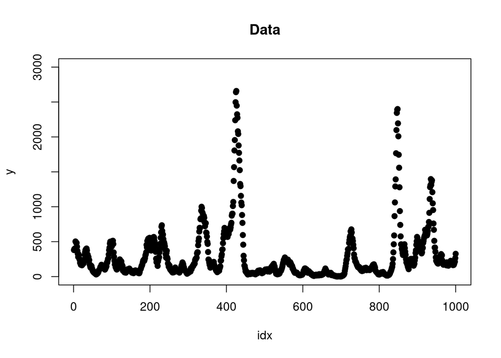

```r
idx <- 1:n
plot(idx, y, pch=19, ylim = range(pretty(y)), main="Data")
```

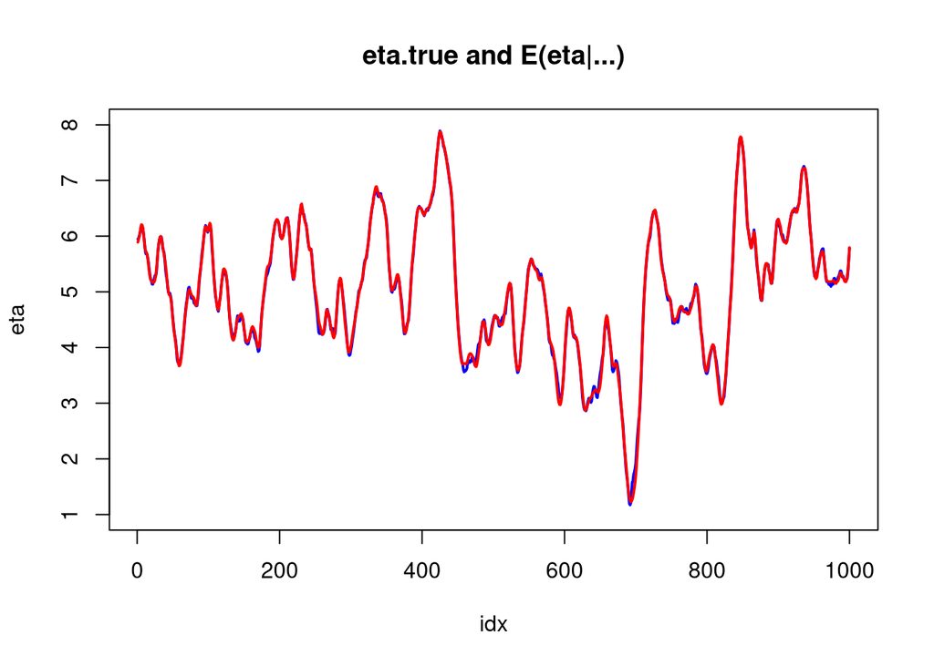

```r
plot(idx, eta, col="blue", lwd=2, type="l", ylim = range(pretty(eta)))
lines(idx, r$summary.linear.predictor$mean, col="red", lwd=2)
title("eta.true and E(eta|...)")
```

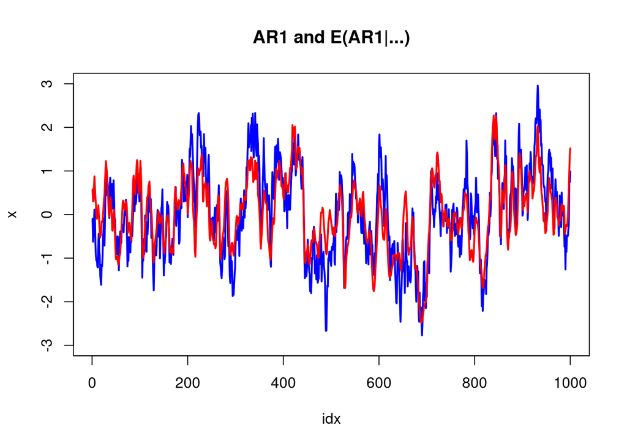

```r
plot(idx, x, col="blue", lwd=2, type="l", ylim = range(pretty(x)))
lines(idx, r$summary.random$idx$mean[1:n], col="red", lwd=2)
title("AR1 and E(AR1|...)")
```

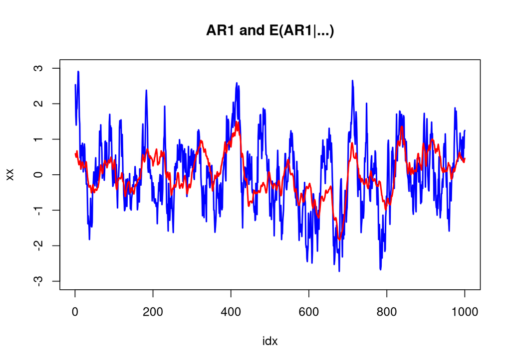

```r
plot(idx, xx, col="blue", lwd=2, type="l", ylim = range(pretty(x)))
lines(idx, r$summary.random$idx$mean[n + 1:n], col="red", lwd=2)
title("AR1 and E(AR1|...)")
```

and the summary is

```r
summary(r)
```

```
## Time used:
##     Pre = 0.125, Running = 2.43, Post = 0.0817, Total = 2.64
## Fixed effects:
##              mean    sd 0.025quant 0.5quant 0.975quant  mode kld
## (Intercept) 5.001 0.004      4.994    5.001      5.009 5.001   0
##
## Random effects:
##   Name     Model
##     idx AR1 model
##
## Model hyperparameters:
##                    mean    sd 0.025quant 0.5quant 0.975quant  mode
## Precision for idx 0.995 0.147      0.727    0.988      1.305 0.979
## Rho for idx       0.922 0.013      0.894    0.923      0.946 0.924
##
## Marginal log-Likelihood:  -4488.73
##  is computed
## Posterior summaries for the linear predictor and the fitted values are computed
## (Posterior marginals needs also 'control.compute=list(return.marginals.predictor=TRUE)')
```

## The `z` model

The new feature gives an easy way to implement the z-model, which is the classic mixed-effect model formulation

$$\eta = \ldots + Z z$$

where $Z$ is a fixed matrix and $z$ is zero mean Normal with precision $\tau Q$. This is implemented in model “z” as follows.

```r
n <- 300
m <- 30
Z <- matrix(rnorm(n*m), n, m)
rho <- 0.8
Qz <- toeplitz(rho^(0:(m-1)))
z <- inla.qsample(1, Q=Qz)
eta <- Z %*% z
s <- 0.1
y <- eta + rnorm(n, sd = s)
```

Using the z-model we get

```r
r <- inla(y ~ -1 + f(idx, model="z", Z=Z, Cmatrix=Qz, precision=exp(20),
                    hyper = list(prec = list(initial = 0, fixed = TRUE))),
        data = list(y=y, idx=1:n, n=n),
        control.family = list(hyper = list(prec = list(initial = log(1/s^2), fixed= TRUE))))
```

Using A.local we get

```r
rr <- inla(y ~ -1 + f(idx, model="generic", A.local=Z, Cmatrix=Qz, values=1:m,
                    hyper = list(prec = list(initial = 0, fixed = TRUE))),
        data = list(y=y, idx=rep(NA,n), n=n, m=m),
        control.family = list(hyper = list(prec = list(initial = log(1/s^2), fixed= TRUE))))
```

and we can compare (noting that “generic” model does not include the normalization constant wrt to the precision matrix; see the documentation)

```r
r$mlik - (rr$mlik + 0.5 * determinant(Qz, log=TRUE)$modulus)
```

```
##                                              [,1]
## log marginal-likelihood (integration) 0.003250527
## log marginal-likelihood (Gaussian)    0.003250527
```

```r
mean(abs(r$summary.random$idx$mean[n + 1:m] - rr$summary.random$idx$mean))
```

```
## [1] 4.940742e-09
```

```r
mean(abs(r$summary.random$idx$sd[n + 1:m] / rr$summary.random$idx$sd - 1))
```

```
## [1] 1.028303e-07
```

## Using replicate, again

This is motivated from an example from the discussion-list, where
$$y = \ldots + \mbox{f(idx, x1, model="besag", ...,
replicate=r1) +
f(idx2, x2, copy="idx", replicate=r2)}$$

where the second term using a replication hence sharing the same hyperparameter. Here its written out for $m=2$ terms, but the aim was several terms like $m\approx 15$.

This can now be done very efficient

```r
g <- inla.read.graph(system.file("demodata/germany.graph", package="INLA"))
source(system.file("demodata/Bym-map.R", package="INLA"))
n <- g$n
m <- 4
s <- 0.1
X <- matrix(rnorm(n*m), n, m)
y <- rowSums(X) + rnorm(n, sd = s)
A <- inla.as.sparse(diag(X[, 1]))
for(i in 2:m) {
    A <- cbind(A, inla.as.sparse(diag(X[, i])))
}

r <- inla(y ~ -1 +
              f(idx.na,
                model = "besag",
                scale.model = TRUE,
                constr = FALSE,
                nrep = m,
                graph = g,
                A.local = A,
                values = 1:n,
                hyper = list(prec = list(prior = "pc.prec",
                                         param = c(0.5, 0.01)))),
          family = "normal",
          control.family = list(hyper = list(prec = list(initial = log(1/s^2),
                                                         fixed = TRUE))),
          data = list(n = n, m = m, y = y, X = X,
              idx.na = rep(NA, n)))
```

```r
beta <- matrix(r$summary.random$idx.na$mean, n,m)
summary(beta)
```

```
##        V1               V2               V3               V4
##  Min.   :0.9994   Min.   :0.9979   Min.   :0.9996   Min.   :0.9997
##  1st Qu.:1.0010   1st Qu.:0.9996   1st Qu.:1.0018   1st Qu.:1.0012
##  Median :1.0016   Median :1.0002   Median :1.0023   Median :1.0020
##  Mean   :1.0016   Mean   :1.0002   Mean   :1.0024   Mean   :1.0021
##  3rd Qu.:1.0021   3rd Qu.:1.0007   3rd Qu.:1.0028   3rd Qu.:1.0029
##  Max.   :1.0037   Max.   :1.0028   Max.   :1.0055   Max.   :1.0062
```

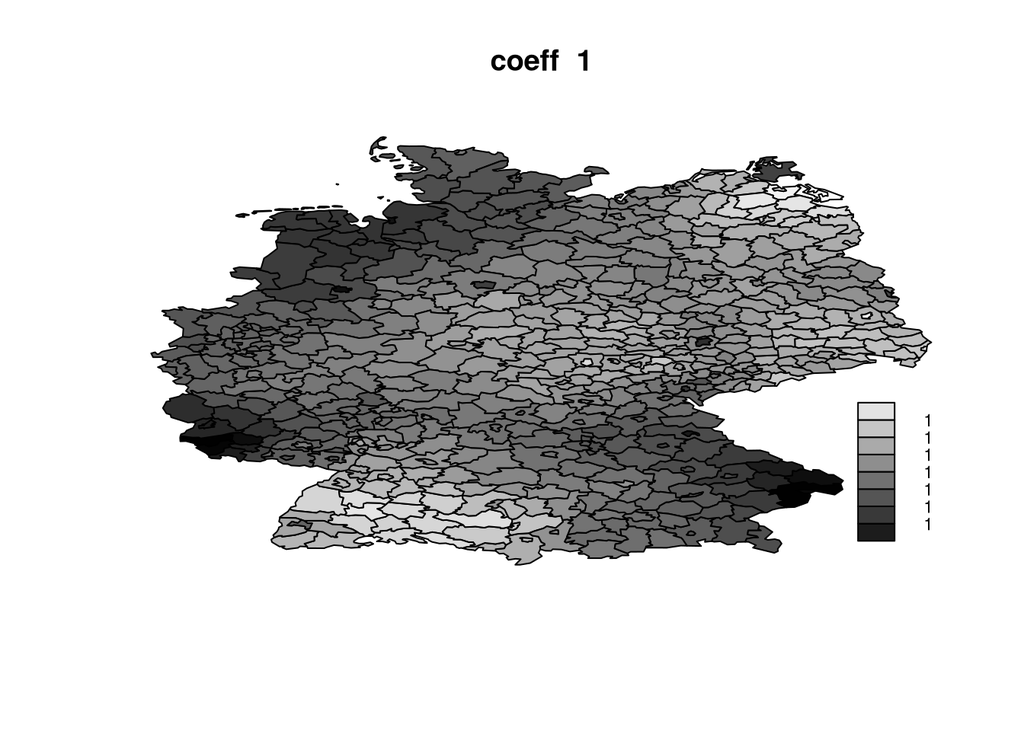

```r
i=1; Bym.map(r$summary.random$idx.na$mean[ (i-1) * n + 1:n])
title(paste("coeff ",  i))
```

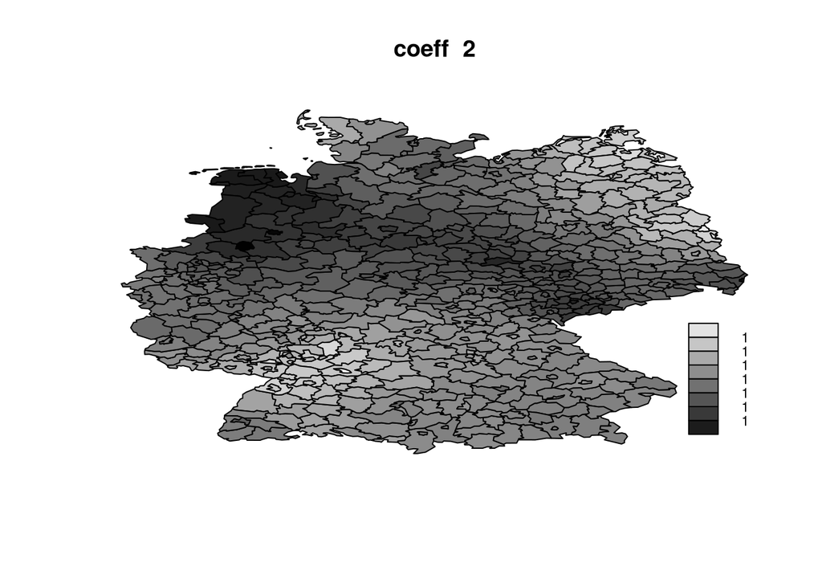

```r
i=2; Bym.map(r$summary.random$idx.na$mean[ (i-1) * n + 1:n])
title(paste("coeff ",  i))
```

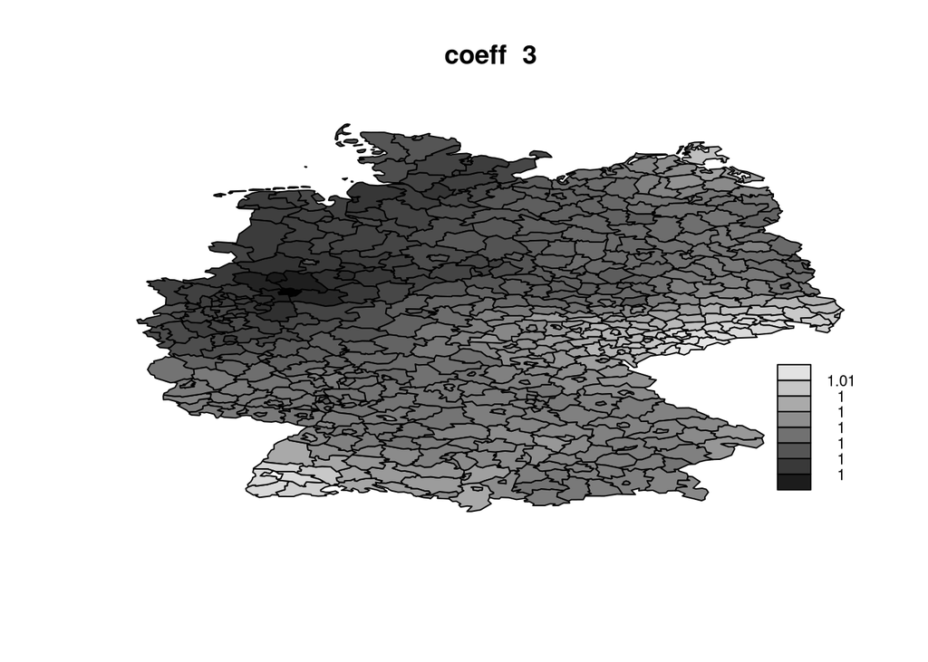

```r
i=3; Bym.map(r$summary.random$idx.na$mean[ (i-1) * n + 1:n])
title(paste("coeff ",  i))
```

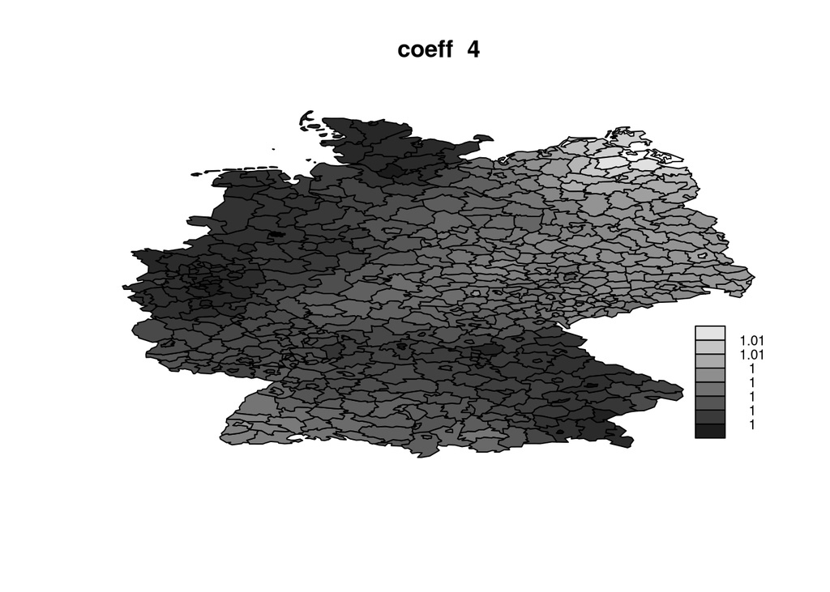

```r
i=4; Bym.map(r$summary.random$idx.na$mean[ (i-1) * n + 1:n])
title(paste("coeff ",  i))
```

## Using ‘Alocal’ in copy

This is to verify that Alocal-feature works as expected with copy. Consider this simple example

```r
n <- 10
y <- 1:n
A <- matrix(0, n, n)
A[lower.tri(A, diag = TRUE)] <- 1
```

where $\eta_i=1, i=1,\ldots,n$ match data $y$ as

```r
cbind(y, A %*% rep(1,n))
```

```
##        y
##  [1,]  1  1
##  [2,]  2  2
##  [3,]  3  3
##  [4,]  4  4
##  [5,]  5  5
##  [6,]  6  6
##  [7,]  7  7
##  [8,]  8  8
##  [9,]  9  9
## [10,] 10 10
```

We can verify that this works as expected with

```r
idx <- 1:n
iidx <- rep(NA, n)
w0 <- rep(0, n)
r <- inla(y ~ -1 +
              f(idx,
                w0,
                model = "iid",
                values = 1:n,
                hyper = list(prec = list(initial = -20,
                                         fixed = TRUE))) +
              f(iidx,
                copy = "idx",
                values = 1:n,
                A.local = A),
          data = list(idx = idx,
                      iidx = iidx,
                      w0 = w0,
                      A = A,
                      n = n),
          family = "stdnormal")
```

The `idx` part only defines the iid model, but is not used, as the weights `w0` are all zero. The distribution is essentially uniform due to the small fixed precision.

The `iidx` part copy `idx`, and then apply matrix `A` in `A.local`. This mean that both `idx` and `iidx` should have mean 1, and the $A$-matrix will make this fit the data.

```r
round(dig=3, cbind(r$summary.random$idx$mean,
                   r$summary.random$iidx$mean))
```

```
##       [,1] [,2]
##  [1,]    1    1
##  [2,]    1    1
##  [3,]    1    1
##  [4,]    1    1
##  [5,]    1    1
##  [6,]    1    1
##  [7,]    1    1
##  [8,]    1    1
##  [9,]    1    1
## [10,]    1    1
```

```r
round(dig=3, cbind(y, A %*% r$summary.random$iidx$mean))
```

```
##        y
##  [1,]  1  1
##  [2,]  2  2
##  [3,]  3  3
##  [4,]  4  4
##  [5,]  5  5
##  [6,]  6  6
##  [7,]  7  7
##  [8,]  8  8
##  [9,]  9  9
## [10,] 10 10
```

If we add scaling this still works

```r
r <- inla(y ~ -1 +
              f(idx,
                w0,
                model = "iid",
                values = 1:n,
                hyper = list(prec = list(initial = -20,
                                         fixed = TRUE))) +
              f(iidx,
                copy = "idx",
                values = 1:n,
                A.local = A,
                hyper = list(beta = list(initial = 0.5))),
          data = list(idx = idx,
                      iidx = iidx,
                      w0 = w0,
                      A = A,
                      n = n),
          family = "stdnormal")
```

Due to the scaling, then `idx` has to bump to $2$, but `iidx` is still $1$ to fit data

```r
round(dig=3, cbind(r$summary.random$idx$mean,
                   r$summary.random$iidx$mean))
```

```
##       [,1] [,2]
##  [1,]    2    1
##  [2,]    2    1
##  [3,]    2    1
##  [4,]    2    1
##  [5,]    2    1
##  [6,]    2    1
##  [7,]    2    1
##  [8,]    2    1
##  [9,]    2    1
## [10,]    2    1
```